# 최적화 문제(Optimization Problem)의 수치해석

1. Optimization of Single Varaiable
   - Golden-Section Search Method(황금분할탐색법)
   - Newton's method(뉴턴-랩슨 방법)
   - Secant method(할선법)
2. Optimization of Multi-Variable
   - Gradient Method(구배법)

## 황금분할탐색법

*Golden-Section Search Method*

### 황금비의 유도

$$ \frac{L_0 }{L_1}=\frac{L_1 }{L_2} = \Phi = \frac{L_1}{L_0-L_1} = \frac{1}{\frac{L_0}{L_1}-1} = \frac{1}{\Phi - 1} \tag{0} $$

$$ \Phi = \frac{1}{\Phi -1} \tag{1} $$

$$ \Phi^2 - \Phi -1 = 0\tag{2} $$

$$ \Phi = \frac{-b \pm\sqrt{b^2 - 4ac}}{2a} = \frac{1+\sqrt{5}}{2} = 1.618033988 $$

$$ \Phi^{-1} = \frac{1}{\Phi} = \frac{\Phi}{1+\Phi}=\frac{1+\sqrt{5}}{3+\sqrt{5}} $$

$$ \because\ \Phi^2 = \Phi + 1,\ \therefore\ \Phi = \frac{\Phi + 1}{\Phi} $$

#### **1. 황금비 정의**

$$ \frac{L_0}{L_1} = \frac{L_1}{L_2} = \Phi $$

- 황금비는 연속적인 두 길이의 비율이 동일한 비율로 정의됩니다.
- 예를 들어, $L_0$, $L_1$, $L_2$가 있을 때:
  - $ \frac{L_0}{L_1} = \Phi $ (전체 길이와 큰 부분의 비율).
  - $ \frac{L_1}{L_2} = \Phi $ (큰 부분과 작은 부분의 비율).
  - 이때 $\Phi$는 동일한 값을 가지며, 이를 황금비라고 부릅니다.

#### **2. 두 값의 차이에 대한 비율**

1. **연속적인 길이의 관계**: $$ L_2 = L_0 - L_1 $$
   - 작은 길이 $L_2$는 전체 길이 $L_0$에서 큰 길이 $L_1$를 뺀 값입니다.
2. **비율 관계 확장**:
   - 큰 부분($L_1$)과 작은 부분($L_0 - L_1$) 사이의 비율 또한 황금비 $\Phi$와 동일합니다: $$ \frac{L_1}{L_0 - L_1} = \Phi $$
     - 여기서, $L_0 - L_1 = L_2$이므로, 이 비율은 $ \frac{L_1}{L_2} $와 동일합니다.

#### **3. 식 정리**

주어진 비율 관계: $$ \frac{L_1}{L_0 - L_1} = \Phi $$

이 식을 정리합니다:

1. 분수를 $\Phi$로 정리: $$ L_1 = \Phi (L_0 - L_1) $$
2. 괄호를 풀고 식을 정리: $$ L_1 = \Phi L_0 - \Phi L_1 $$
3. $L_1$ 항목을 한쪽으로 모읍니다: $$ L_1 + \Phi L_1 = \Phi L_0 $$
4. $L_1$로 묶습니다: $$ L_1 (1 + \Phi) = \Phi L_0 $$
5. $L_0 / L_1$로 변형: $$ \frac{L_0}{L_1} = \frac{1 + \Phi}{\Phi} $$

#### **4. 황금비의 역수 관계**

$$ \Phi=\frac{L_1}{L_0-L_1} = \frac{1}{\frac{L_0}{L_1}-1} = \frac{1}{\Phi - 1} \tag{0} $$

- 이 관계는 위의 $(0)$식을 통해 유도됩니다:
  - $ \frac{L_0}{L_1} = \Phi $
  - $ \frac{L_1}{L_2} = \Phi $
  - 따라서, $\Phi$는 자기 자신과 역수 관계를 가집니다.

이 식을 통해 황금비의 본질적 특성이 드러납니다:

- 황금비는 연속적인 두 길이의 비율이 동일한 구조를 가지며, 동시에 자기 자신과 특정 대칭 관계($\Phi = \frac{1}{\Phi - 1}$)를 만족합니다.

#### **요약**

이 부분에서 중요한 핵심은:

1. **연속적인 비율 관계**: $$ \frac{L_0}{L_1} = \frac{L_1}{L_2} = \Phi $$
2. **황금비와 자기 반복적 특성**: $$ \Phi = \frac{1}{\Phi - 1} $$

#### **1. 재구성**

$$ \Phi = \frac{1}{\Phi - 1} $$

- $\Phi - 1$을 분모로 가지는 표현으로 변형합니다.

양변에 $(\Phi - 1)$를 곱하면: $$ \Phi (\Phi - 1) = 1 $$

분배법칙을 적용하면: $$ \Phi^2 - \Phi = 1 $$

#### **2. 이차방정식으로 변환**

$$ \Phi^2 - \Phi - 1 = 0 $$

- 위 식은 이차방정식 형태로 변환됩니다.

이차방정식 $ax^2 + bx + c = 0$의 해 공식에 따라: $$ x = \frac{-b \pm \sqrt{b^2 - 4ac}}{2a} $$

여기서:

- $a = 1$, $b = -1$, $c = -1$.

대입하면: $$ \Phi = \frac{-(-1) \pm \sqrt{(-1)^2 - 4(1)(-1)}}{2(1)} $$

$$ \Phi = \frac{1 \pm \sqrt{1 + 4}}{2} $$

$$ \Phi = \frac{1 \pm \sqrt{5}}{2} $$

#### **3. 황금비 선택**

$$ \Phi = \frac{1 + \sqrt{5}}{2} $$

- 이 두 해 중 $\Phi = \frac{1 + \sqrt{5}}{2}$만 선택됩니다. 이는 $\Phi$가 항상 양수이기 때문입니다.

계산하면: $$ \Phi \approx 1.618033988 $$

#### **4. 역수 관계**

$$ \Phi^{-1} = \frac{1}{\Phi} $$

- $\Phi$의 역수를 구합니다.

$\Phi$의 정의에서: $$ \Phi = 1 + \Phi^{-1} $$

즉: $$ \Phi^{-1} = \Phi - 1 $$

이 관계는 다음과 같이 정리될 수 있습니다: $$ \Phi^{-1} = \frac{\Phi}{1 + \Phi} $$

#### **5. 추가 관계**

황금비 $\Phi$의 성질에 따라: $$ \Phi^2 = \Phi + 1 $$

- 이는 초기 이차방정식 $\Phi^2 - \Phi - 1 = 0$에서 유도할 수 있습니다.

또한: $$ \Phi = \frac{\Phi + 1}{\Phi} $$

- 이는 위의 역수 관계와 일치하며, $\Phi$의 대칭성을 보여줍니다.

#### **6. 요약**

황금비는 연속적인 비율 관계를 유지하는 특별한 값으로 정의되며, 다음과 같은 성질을 가집니다:

1. $\Phi = \frac{1 + \sqrt{5}}{2} \approx 1.618033988$
2. $\Phi^2 = \Phi + 1$
3. $\Phi^{-1} = \Phi - 1$

이러한 성질은 기하학, 예술, 자연 등 다양한 분야에서 응용됩니다.

### 1. 초기 설정

탐색 구간 $[a, b]$에서 최소값을 찾는다고 가정합니다.

1. 구간을 두 내부 점 $ x_1 $과 $ x_2 $로 나눕니다.
2. 이때 $ x_1 $과 $ x_2 $는 **황금비를 기준**으로 정의됩니다: $$ x_1 = b - \frac{b - a}{\Phi}, \quad x_2 = a + \frac{b - a}{\Phi} $$ 여기서 $\Phi = \frac{1 + \sqrt{5}}{2} \approx 1.618$입니다.

이렇게 하면 구간을 나누는 비율이 **황금비**에 의해 일정하게 유지됩니다.

### 2. 함수 값 비교 및 구간 축소

1. 함수 $f(x)$의 최소값을 찾는 과정에서, $f(x_1)$과 $f(x_2)$를 계산하고 두 값을 비교합니다.
2. 만약 $f(x_1) < f(x_2)$인 경우, 최소값이 왼쪽 구간에 있을 가능성이 높으므로, **구간을 $[a, x_2]$로 축소**합니다.
   - 새로운 구간: $[a, x_2]$
   - **구간이 축소**되면서, 기존의 $x_1$은 새로운 $x_2$로 **재사용**됩니다.
3. 반대로 $f(x_1) > f(x_2)$인 경우, 최소값이 오른쪽 구간에 있을 가능성이 높으므로, **구간을 $[x_1, b]$로 축소**합니다.
   - 새로운 구간: $[x_1, b]$
   - **구간이 축소**되면서, 기존의 $x_2$는 새로운 $x_1$로 **재사용**됩니다.

### 3. 구간 축소 반복 및 최적화 수렴

위 과정을 반복하면서 구간을 점점 줄여 나가면, **구간의 길이가 점점 짧아져** 최소값이 위치한 지점에 수렴하게 됩니다.

### 4. 황금분할탐색법의 효율성

- 구간을 축소할 때 **황금비에 따라 나누면** 이전 단계에서 계산한 함수 값을 **재사용**할 수 있습니다.
- $x_1$과 $x_2$ 중 하나의 점을 그대로 유지하면서 새로운 구간에서 **다른 점 하나만 새로 계산**하면 되므로 계산량을 줄일 수 있습니다.

### 최종 요약 수식

1. **초기 분할**: $$ x_1 = b - \frac{b - a}{\Phi}, \quad x_2 = a + \frac{b - a}{\Phi} $$
2. **구간 축소 및 점 재사용**:
   - $f(x_1) < f(x_2)$이면, $[a, x_2]$로 축소 $$ x_2^{new} = x_1, \quad x_1 = b - \frac{b - a}{\Phi} $$

     $$ x_1^{new} = x_2 - \frac{b - a}{\Phi} $$
   - $f(x_1) > f(x_2)$이면, $[x_1, b]$로 축소 $$ x_1^{new} = x_2, \quad x_2 = a + \frac{b - a}{\Phi} $$

     $$ x_2^{new} = x_1 + \frac{b - a}{\Phi} $$

황금비를 사용하여 구간을 축소함으로써 효율적으로 최소값을 탐색할 수 있습니다.

### 예제

#### 교재 p.217 II-7-1

$$ f(x) = 2\cos{x} + x - \frac{x^2}{10} $$

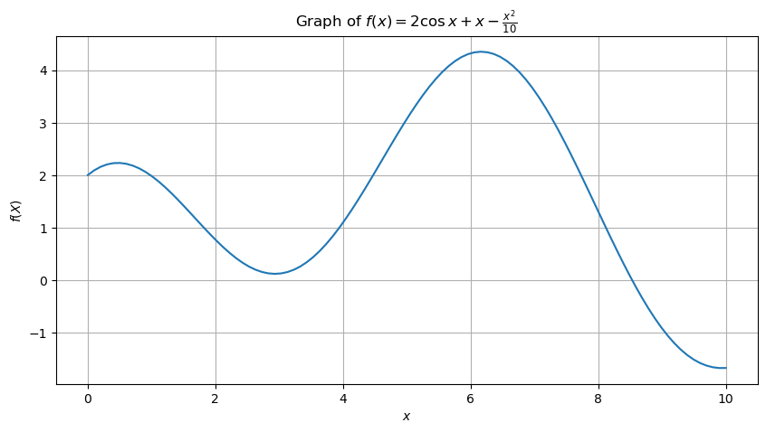

```python
import matplotlib.pyplot as plt
import numpy as np

x = np.linspace(0, 10, 100)

def f(x: np.array) -> np.array:
    return 2 * np.cos(x) + x - x*x/10

fx = f(x)

plt.figure(figsize=(10,5))
plt.plot(x, fx)
plt.title(r'Graph of $f(x) = 2\cos{x} + x - \frac{x^2}{10}$')
plt.ylabel(r'$f(X)$')
plt.xlabel(r'$x$')
plt.grid()
plt.show()
```

```
Iteration 1: Interval = [4.000000, 8.000000], x1 = 5.527864, x2 = 6.472136, f(x1) = 3.928239, f(x2) = 4.247685
Iteration 2: Interval = [5.527864, 8.000000], x1 = 6.472136, x2 = 7.055728, f(x1) = 4.247685, f(x2) = 3.509675
Iteration 3: Interval = [5.527864, 7.055728], x1 = 6.111456, x2 = 6.472136, f(x1) = 4.347048, f(x2) = 4.247685
Iteration 4: Interval = [5.527864, 6.472136], x1 = 5.888544, x2 = 6.111456, f(x1) = 4.267318, f(x2) = 4.347048
Iteration 5: Interval = [5.888544, 6.472136], x1 = 6.111456, x2 = 6.249224, f(x1) = 4.347048, f(x2) = 4.342791
Iteration 6: Interval = [5.888544, 6.249224], x1 = 6.026311, x2 = 6.111456, f(x1) = 4.329046, f(x2) = 4.347048
Iteration 7: Interval = [6.026311, 6.249224], x1 = 6.111456, x2 = 6.164079, f(x1) = 4.347048, f(x2) = 4.350322
Iteration 8: Interval = [6.111456, 6.249224], x1 = 6.164079, x2 = 6.196601, f(x1) = 4.350322, f(x2) = 4.349322
Iteration 9: Interval = [6.111456, 6.196601], x1 = 6.143979, x2 = 6.164079, f(x1) = 4.349784, f(x2) = 4.350322
Iteration 10: Interval = [6.143979, 6.196601], x1 = 6.164079, x2 = 6.176501, f(x1) = 4.350322, f(x2) = 4.350214
Iteration 11: Interval = [6.143979, 6.176501], x1 = 6.156401, x2 = 6.164079, f(x1) = 4.350221, f(x2) = 4.350322
Iteration 12: Interval = [6.156401, 6.176501], x1 = 6.164079, x2 = 6.168824, f(x1) = 4.350322, f(x2) = 4.350321
Iteration 13: Interval = [6.156401, 6.168824], x1 = 6.161146, x2 = 6.164079, f(x1) = 4.350299, f(x2) = 4.350322
Iteration 14: Interval = [6.161146, 6.168824], x1 = 6.164079, x2 = 6.165891, f(x1) = 4.350322, f(x2) = 4.350328
Iteration 15: Interval = [6.164079, 6.168824], x1 = 6.165891, x2 = 6.167011, f(x1) = 4.350328, f(x2) = 4.350327
Iteration 16: Interval = [6.164079, 6.167011], x1 = 6.165199, x2 = 6.165891, f(x1) = 4.350327, f(x2) = 4.350328
Iteration 17: Interval = [6.165199, 6.167011], x1 = 6.165891, x2 = 6.166319, f(x1) = 4.350328, f(x2) = 4.350328
Iteration 18: Interval = [6.165891, 6.167011], x1 = 6.166319, x2 = 6.166583, f(x1) = 4.350328, f(x2) = 4.350328
Iteration 19: Interval = [6.165891, 6.166583], x1 = 6.166155, x2 = 6.166319, f(x1) = 4.350328, f(x2) = 4.350328
Iteration 20: Interval = [6.166155, 6.166583], x1 = 6.166319, x2 = 6.166420, f(x1) = 4.350328, f(x2) = 4.350328
Iteration 21: Interval = [6.166155, 6.166420], x1 = 6.166256, x2 = 6.166319, f(x1) = 4.350328, f(x2) = 4.350328
Iteration 22: Interval = [6.166256, 6.166420], x1 = 6.166319, x2 = 6.166357, f(x1) = 4.350328, f(x2) = 4.350328
Iteration 23: Interval = [6.166256, 6.166357], x1 = 6.166295, x2 = 6.166319, f(x1) = 4.350328, f(x2) = 4.350328
Iteration 24: Interval = [6.166256, 6.166319], x1 = 6.166280, x2 = 6.166295, f(x1) = 4.350328, f(x2) = 4.350328
Iteration 25: Interval = [6.166280, 6.166319], x1 = 6.166295, x2 = 6.166304, f(x1) = 4.350328, f(x2) = 4.350328
Iteration 26: Interval = [6.166280, 6.166304], x1 = 6.166289, x2 = 6.166295, f(x1) = 4.350328, f(x2) = 4.350328
Iteration 27: Interval = [6.166280, 6.166295], x1 = 6.166286, x2 = 6.166289, f(x1) = 4.350328, f(x2) = 4.350328
Iteration 28: Interval = [6.166286, 6.166295], x1 = 6.166289, x2 = 6.166292, f(x1) = 4.350328, f(x2) = 4.350328
Iteration 29: Interval = [6.166286, 6.166292], x1 = 6.166288, x2 = 6.166289, f(x1) = 4.350328, f(x2) = 4.350328
Iteration 30: Interval = [6.166288, 6.166292], x1 = 6.166289, x2 = 6.166290, f(x1) = 4.350328, f(x2) = 4.350328
Iteration 31: Interval = [6.166289, 6.166292], x1 = 6.166290, x2 = 6.166291, f(x1) = 4.350328, f(x2) = 4.350328
Iteration 32: Interval = [6.166289, 6.166291], x1 = 6.166290, x2 = 6.166290, f(x1) = 4.350328, f(x2) = 4.350328
Iteration 33: Interval = [6.166290, 6.166291], x1 = 6.166290, x2 = 6.166290, f(x1) = 4.350328, f(x2) = 4.350328
Iteration 34: Interval = [6.166290, 6.166290], x1 = 6.166290, x2 = 6.166290, f(x1) = 4.350328, f(x2) = 4.350328
Iteration 35: Interval = [6.166290, 6.166290], x1 = 6.166290, x2 = 6.166290, f(x1) = 4.350328, f(x2) = 4.350328
Iteration 36: Interval = [6.166290, 6.166290], x1 = 6.166290, x2 = 6.166290, f(x1) = 4.350328, f(x2) = 4.350328
Iteration 37: Interval = [6.166290, 6.166290], x1 = 6.166290, x2 = 6.166290, f(x1) = 4.350328, f(x2) = 4.350328
Iteration 38: Interval = [6.166290, 6.166290], x1 = 6.166290, x2 = 6.166290, f(x1) = 4.350328, f(x2) = 4.350328
Iteration 39: Interval = [6.166290, 6.166290], x1 = 6.166290, x2 = 6.166290, f(x1) = 4.350328, f(x2) = 4.350328
Iteration 40: Interval = [6.166290, 6.166290], x1 = 6.166290, x2 = 6.166290, f(x1) = 4.350328, f(x2) = 4.350328
Iteration 41: Interval = [6.166290, 6.166290], x1 = 6.166290, x2 = 6.166290, f(x1) = 4.350328, f(x2) = 4.350328
Iteration 42: Interval = [6.166290, 6.166290], x1 = 6.166290, x2 = 6.166290, f(x1) = 4.350328, f(x2) = 4.350328
Iteration 43: Interval = [6.166290, 6.166290], x1 = 6.166290, x2 = 6.166290, f(x1) = 4.350328, f(x2) = 4.350328
Iteration 44: Interval = [6.166290, 6.166290], x1 = 6.166290, x2 = 6.166290, f(x1) = 4.350328, f(x2) = 4.350328
Iteration 45: Interval = [6.166290, 6.166290], x1 = 6.166290, x2 = 6.166290, f(x1) = 4.350328, f(x2) = 4.350328
Iteration 46: Interval = [6.166290, 6.166290], x1 = 6.166290, x2 = 6.166290, f(x1) = 4.350328, f(x2) = 4.350328
Iteration 47: Interval = [6.166290, 6.166290], x1 = 6.166290, x2 = 6.166290, f(x1) = 4.350328, f(x2) = 4.350328
Iteration 48: Interval = [6.166290, 6.166290], x1 = 6.166290, x2 = 6.166290, f(x1) = 4.350328, f(x2) = 4.350328
Iteration 49: Interval = [6.166290, 6.166290], x1 = 6.166290, x2 = 6.166290, f(x1) = 4.350328, f(x2) = 4.350328
Iteration 50: Interval = [6.166290, 6.166290], x1 = 6.166290, x2 = 6.166290, f(x1) = 4.350328, f(x2) = 4.350328
Iteration 51: Interval = [6.166290, 6.166290], x1 = 6.166290, x2 = 6.166290, f(x1) = 4.350328, f(x2) = 4.350328
Iteration 52: Interval = [6.166290, 6.166290], x1 = 6.166290, x2 = 6.166290, f(x1) = 4.350328, f(x2) = 4.350328

Converged: xm = 6.166290, f(xm) = 4.350328
```

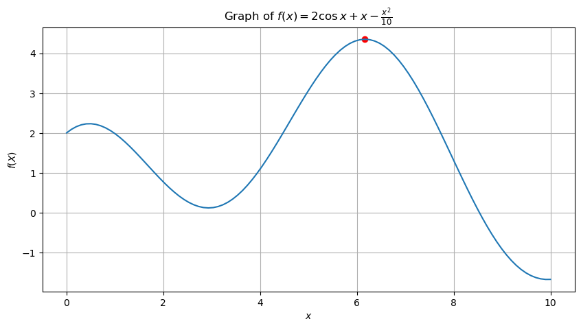

```python
from Optimization import Optimizer
import numpy as np

def f(x):
    return (2.0*np.cos(x)+x-x*x/10.0)


opt = Optimizer(f=f)
xm, extreme_value, max_iter = opt.GoldenSearch(xL=4, xR=8)

import matplotlib.pyplot as plt
import numpy as np

x = np.linspace(0, 10, 100)

def f(x: np.array) -> np.array:
    return 2 * np.cos(x) + x - x*x/10

fx = f(x)

plt.figure(figsize=(10,5))
plt.plot(x, fx)
plt.title(r'Graph of $f(x) = 2\cos{x} + x - \frac{x^2}{10}$')
plt.scatter(xm, extreme_value, c='r')
plt.ylabel(r'$f(X)$')
plt.xlabel(r'$x$')
plt.grid()
plt.show()
```

#### Chapra Ch.7 PROBLEM 7.33

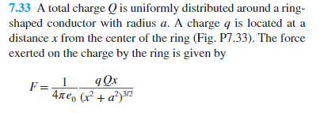

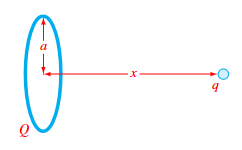

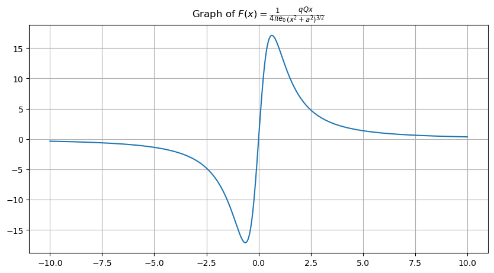

```python
def F(x):
    return (1/(4*np.pi*8.85*10e-12))*((2*10e-5*2*10e-5*x)/(x*x+0.9*0.9)**1.5)

x = np.linspace(-10, 10, 1000)

plt.figure(figsize=(10,5))
plt.plot(x, F(x))
plt.title(r'Graph of $F(x) = \frac{1}{4\pi e_0} \frac{qQx}{(x^2+a^2)^{3/2}}$')
plt.grid()
plt.show()
```

```
Iteration 1: Interval = [0.500000, 0.700000], x1 = 0.576393, x2 = 0.623607, f(x1) = 16.982275, f(x2) = 17.086424
Iteration 2: Interval = [0.576393, 0.700000], x1 = 0.623607, x2 = 0.652786, f(x1) = 17.086424, f(x2) = 17.083690
Iteration 3: Interval = [0.576393, 0.652786], x1 = 0.605573, x2 = 0.623607, f(x1) = 17.063354, f(x2) = 17.086424
Iteration 4: Interval = [0.605573, 0.652786], x1 = 0.623607, x2 = 0.634752, f(x1) = 17.086424, f(x2) = 17.091021
Iteration 5: Interval = [0.623607, 0.652786], x1 = 0.634752, x2 = 0.641641, f(x1) = 17.091021, f(x2) = 17.090329
Iteration 6: Interval = [0.623607, 0.641641], x1 = 0.630495, x2 = 0.634752, f(x1) = 17.090111, f(x2) = 17.091021
Iteration 7: Interval = [0.630495, 0.641641], x1 = 0.634752, x2 = 0.637384, f(x1) = 17.091021, f(x2) = 17.091070
Iteration 8: Interval = [0.634752, 0.641641], x1 = 0.637384, x2 = 0.639010, f(x1) = 17.091070, f(x2) = 17.090906
Iteration 9: Interval = [0.634752, 0.639010], x1 = 0.636379, x2 = 0.637384, f(x1) = 17.091097, f(x2) = 17.091070
Iteration 10: Interval = [0.634752, 0.637384], x1 = 0.635757, x2 = 0.636379, f(x1) = 17.091086, f(x2) = 17.091097
Iteration 11: Interval = [0.635757, 0.637384], x1 = 0.636379, x2 = 0.636762, f(x1) = 17.091097, f(x2) = 17.091094
Iteration 12: Interval = [0.635757, 0.636762], x1 = 0.636141, x2 = 0.636379, f(x1) = 17.091096, f(x2) = 17.091097
Iteration 13: Interval = [0.636141, 0.636762], x1 = 0.636379, x2 = 0.636525, f(x1) = 17.091097, f(x2) = 17.091097
Iteration 14: Interval = [0.636141, 0.636525], x1 = 0.636288, x2 = 0.636379, f(x1) = 17.091097, f(x2) = 17.091097
Iteration 15: Interval = [0.636288, 0.636525], x1 = 0.636379, x2 = 0.636435, f(x1) = 17.091097, f(x2) = 17.091097
Iteration 16: Interval = [0.636288, 0.636435], x1 = 0.636344, x2 = 0.636379, f(x1) = 17.091097, f(x2) = 17.091097
Iteration 17: Interval = [0.636344, 0.636435], x1 = 0.636379, x2 = 0.636400, f(x1) = 17.091097, f(x2) = 17.091097
Iteration 18: Interval = [0.636379, 0.636435], x1 = 0.636400, x2 = 0.636413, f(x1) = 17.091097, f(x2) = 17.091097
Iteration 19: Interval = [0.636379, 0.636413], x1 = 0.636392, x2 = 0.636400, f(x1) = 17.091097, f(x2) = 17.091097
Iteration 20: Interval = [0.636392, 0.636413], x1 = 0.636400, x2 = 0.636405, f(x1) = 17.091097, f(x2) = 17.091097
Iteration 21: Interval = [0.636392, 0.636405], x1 = 0.636397, x2 = 0.636400, f(x1) = 17.091097, f(x2) = 17.091097
Iteration 22: Interval = [0.636392, 0.636400], x1 = 0.636395, x2 = 0.636397, f(x1) = 17.091097, f(x2) = 17.091097
Iteration 23: Interval = [0.636395, 0.636400], x1 = 0.636397, x2 = 0.636398, f(x1) = 17.091097, f(x2) = 17.091097
Iteration 24: Interval = [0.636395, 0.636398], x1 = 0.636396, x2 = 0.636397, f(x1) = 17.091097, f(x2) = 17.091097
Iteration 25: Interval = [0.636395, 0.636397], x1 = 0.636396, x2 = 0.636396, f(x1) = 17.091097, f(x2) = 17.091097
Iteration 26: Interval = [0.636396, 0.636397], x1 = 0.636396, x2 = 0.636396, f(x1) = 17.091097, f(x2) = 17.091097
Iteration 27: Interval = [0.636396, 0.636396], x1 = 0.636396, x2 = 0.636396, f(x1) = 17.091097, f(x2) = 17.091097
Iteration 28: Interval = [0.636396, 0.636396], x1 = 0.636396, x2 = 0.636396, f(x1) = 17.091097, f(x2) = 17.091097
Iteration 29: Interval = [0.636396, 0.636396], x1 = 0.636396, x2 = 0.636396, f(x1) = 17.091097, f(x2) = 17.091097
Iteration 30: Interval = [0.636396, 0.636396], x1 = 0.636396, x2 = 0.636396, f(x1) = 17.091097, f(x2) = 17.091097
Iteration 31: Interval = [0.636396, 0.636396], x1 = 0.636396, x2 = 0.636396, f(x1) = 17.091097, f(x2) = 17.091097
Iteration 32: Interval = [0.636396, 0.636396], x1 = 0.636396, x2 = 0.636396, f(x1) = 17.091097, f(x2) = 17.091097
Iteration 33: Interval = [0.636396, 0.636396], x1 = 0.636396, x2 = 0.636396, f(x1) = 17.091097, f(x2) = 17.091097
Iteration 34: Interval = [0.636396, 0.636396], x1 = 0.636396, x2 = 0.636396, f(x1) = 17.091097, f(x2) = 17.091097
Iteration 35: Interval = [0.636396, 0.636396], x1 = 0.636396, x2 = 0.636396, f(x1) = 17.091097, f(x2) = 17.091097
Iteration 36: Interval = [0.636396, 0.636396], x1 = 0.636396, x2 = 0.636396, f(x1) = 17.091097, f(x2) = 17.091097
Iteration 37: Interval = [0.636396, 0.636396], x1 = 0.636396, x2 = 0.636396, f(x1) = 17.091097, f(x2) = 17.091097
Iteration 38: Interval = [0.636396, 0.636396], x1 = 0.636396, x2 = 0.636396, f(x1) = 17.091097, f(x2) = 17.091097
Iteration 39: Interval = [0.636396, 0.636396], x1 = 0.636396, x2 = 0.636396, f(x1) = 17.091097, f(x2) = 17.091097
Iteration 40: Interval = [0.636396, 0.636396], x1 = 0.636396, x2 = 0.636396, f(x1) = 17.091097, f(x2) = 17.091097
Iteration 41: Interval = [0.636396, 0.636396], x1 = 0.636396, x2 = 0.636396, f(x1) = 17.091097, f(x2) = 17.091097
Iteration 42: Interval = [0.636396, 0.636396], x1 = 0.636396, x2 = 0.636396, f(x1) = 17.091097, f(x2) = 17.091097
Iteration 43: Interval = [0.636396, 0.636396], x1 = 0.636396, x2 = 0.636396, f(x1) = 17.091097, f(x2) = 17.091097
Iteration 44: Interval = [0.636396, 0.636396], x1 = 0.636396, x2 = 0.636396, f(x1) = 17.091097, f(x2) = 17.091097
Iteration 45: Interval = [0.636396, 0.636396], x1 = 0.636396, x2 = 0.636396, f(x1) = 17.091097, f(x2) = 17.091097
Iteration 46: Interval = [0.636396, 0.636396], x1 = 0.636396, x2 = 0.636396, f(x1) = 17.091097, f(x2) = 17.091097

Converged: xm = 0.636396, f(xm) = 17.091097
```

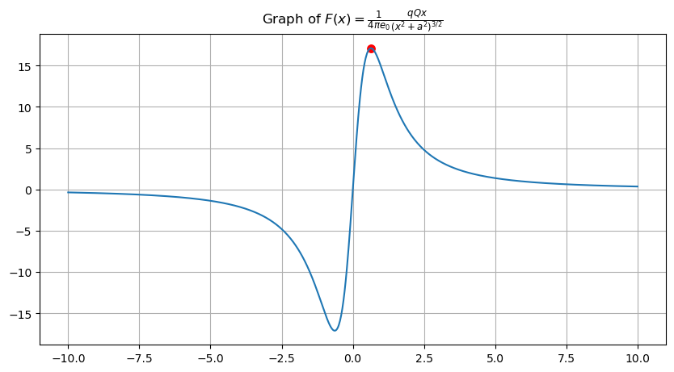

```python
opt = Optimizer(f=F)

res = opt.GoldenSearch(xL=0.5, xR=0.7)

def F(x):
    return (1/(4*np.pi*8.85*10e-12))*((2*10e-5*2*10e-5*x)/(x*x+0.9*0.9)**1.5)

x = np.linspace(-10, 10, 1000)

plt.figure(figsize=(10,5))
plt.plot(x, F(x))
plt.scatter(*res, c='r')
plt.title(r'Graph of $F(x) = \frac{1}{4\pi e_0} \frac{qQx}{(x^2+a^2)^{3/2}}$')
plt.grid()
plt.show()
```

#### Chapra Ch.7 PROBLEM 7.39

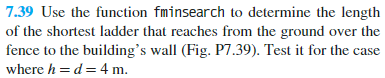

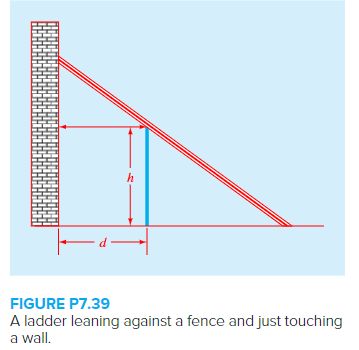

위쪽 삼각형의 빗변 길이:

$$ \frac{d}{L_1} = \cos{x} $$

$$ \frac{L_1}{d} = \frac{1}{\cos{x}} $$

$$ L_1 = \frac{d}{\cos{x}} $$

아래쪽 삼각형의 빗변 길이:

$$ \frac{h}{L_2} = \sin{x} $$

$$ \frac{L_2}{h} = \frac{1}{\sin{x}} $$

$$ L_2 = \frac{h}{\sin{x}} $$

길이 최소화 식:

$$ \min_{x} L_1 + L_2 = \frac{d}{\cos{x}} + \frac{h}{\sin{x}}, \quad (0<x<\pi/2) $$

삼각형의 한 각의(오른쪽 아래 모서리, 위아래 동일) 최대 각도는 $\pi - \frac{\pi}{2} = \frac{\pi}{2}$로 제한

음수를 취해 최대화 문제로 변환:

$$ \max_{x} -(L_1 + L_2) = -\left(\frac{d}{\cos{x}} + \frac{h}{\sin{x}}\right), \quad (0<x<\pi/2) $$

```python
# 피타고라스 정리
from math import sqrt
solution = sqrt(32) + sqrt(32)
solution
```

```
11.313708498984761
```

```python
from math import cos, sin, sqrt, pi

def ladder(x):
    return -(4/cos(x) + 4/sin(x))

opt = Optimizer(f=ladder)
xm, max, iter = opt.GoldenSearch(xL=0, xR=pi/2)
print(f'Angle: {xm}, Minimum Ladder length: {-max}')
```

```
Iteration 1: Interval = [0.000000, 1.570796], x1 = 0.599991, x2 = 0.970806, f(x1) = -11.930707, f(x2) = -11.930707
Iteration 2: Interval = [0.599991, 1.570796], x1 = 0.970806, x2 = 1.199982, f(x1) = -11.930707, f(x2) = -15.329989
Iteration 3: Interval = [0.599991, 1.199982], x1 = 0.829167, x2 = 0.970806, f(x1) = -11.346318, f(x2) = -11.930707
Iteration 4: Interval = [0.599991, 0.970806], x1 = 0.741629, x2 = 0.829167, f(x1) = -11.346318, f(x2) = -11.346318
Iteration 5: Interval = [0.741629, 0.970806], x1 = 0.829167, x2 = 0.883268, f(x1) = -11.346318, f(x2) = -11.478765
Iteration 6: Interval = [0.741629, 0.883268], x1 = 0.795731, x2 = 0.829167, f(x1) = -11.315521, f(x2) = -11.346318
Iteration 7: Interval = [0.741629, 0.829167], x1 = 0.775066, x2 = 0.795731, f(x1) = -11.315521, f(x2) = -11.315521
Iteration 8: Interval = [0.741629, 0.795731], x1 = 0.762294, x2 = 0.775066, f(x1) = -11.322775, f(x2) = -11.315521
Iteration 9: Interval = [0.762294, 0.795731], x1 = 0.775066, x2 = 0.782959, f(x1) = -11.315521, f(x2) = -11.313809
Iteration 10: Interval = [0.775066, 0.795731], x1 = 0.782959, x2 = 0.787837, f(x1) = -11.313809, f(x2) = -11.313809
Iteration 11: Interval = [0.775066, 0.787837], x1 = 0.779944, x2 = 0.782959, f(x1) = -11.314213, f(x2) = -11.313809
Iteration 12: Interval = [0.779944, 0.787837], x1 = 0.782959, x2 = 0.784822, f(x1) = -11.313809, f(x2) = -11.313714
Iteration 13: Interval = [0.782959, 0.787837], x1 = 0.784822, x2 = 0.785974, f(x1) = -11.313714, f(x2) = -11.313714
Iteration 14: Interval = [0.782959, 0.785974], x1 = 0.784111, x2 = 0.784822, f(x1) = -11.313737, f(x2) = -11.313714
Iteration 15: Interval = [0.784111, 0.785974], x1 = 0.784822, x2 = 0.785262, f(x1) = -11.313714, f(x2) = -11.313709
Iteration 16: Interval = [0.784822, 0.785974], x1 = 0.785262, x2 = 0.785534, f(x1) = -11.313709, f(x2) = -11.313709
Iteration 17: Interval = [0.784822, 0.785534], x1 = 0.785094, x2 = 0.785262, f(x1) = -11.313710, f(x2) = -11.313709
Iteration 18: Interval = [0.785094, 0.785534], x1 = 0.785262, x2 = 0.785366, f(x1) = -11.313709, f(x2) = -11.313709
Iteration 19: Interval = [0.785262, 0.785534], x1 = 0.785366, x2 = 0.785430, f(x1) = -11.313709, f(x2) = -11.313709
Iteration 20: Interval = [0.785366, 0.785534], x1 = 0.785430, x2 = 0.785470, f(x1) = -11.313709, f(x2) = -11.313709
Iteration 21: Interval = [0.785366, 0.785470], x1 = 0.785406, x2 = 0.785430, f(x1) = -11.313708, f(x2) = -11.313709
Iteration 22: Interval = [0.785366, 0.785430], x1 = 0.785391, x2 = 0.785406, f(x1) = -11.313708, f(x2) = -11.313708
Iteration 23: Interval = [0.785366, 0.785406], x1 = 0.785381, x2 = 0.785391, f(x1) = -11.313709, f(x2) = -11.313708
Iteration 24: Interval = [0.785381, 0.785406], x1 = 0.785391, x2 = 0.785396, f(x1) = -11.313708, f(x2) = -11.313708
Iteration 25: Interval = [0.785391, 0.785406], x1 = 0.785396, x2 = 0.785400, f(x1) = -11.313708, f(x2) = -11.313708
Iteration 26: Interval = [0.785391, 0.785400], x1 = 0.785394, x2 = 0.785396, f(x1) = -11.313708, f(x2) = -11.313708
Iteration 27: Interval = [0.785394, 0.785400], x1 = 0.785396, x2 = 0.785398, f(x1) = -11.313708, f(x2) = -11.313708
Iteration 28: Interval = [0.785396, 0.785400], x1 = 0.785398, x2 = 0.785399, f(x1) = -11.313708, f(x2) = -11.313708
Iteration 29: Interval = [0.785398, 0.785400], x1 = 0.785399, x2 = 0.785399, f(x1) = -11.313708, f(x2) = -11.313708
Iteration 30: Interval = [0.785398, 0.785399], x1 = 0.785398, x2 = 0.785399, f(x1) = -11.313708, f(x2) = -11.313708
Iteration 31: Interval = [0.785398, 0.785399], x1 = 0.785398, x2 = 0.785398, f(x1) = -11.313708, f(x2) = -11.313708
Iteration 32: Interval = [0.785398, 0.785398], x1 = 0.785398, x2 = 0.785398, f(x1) = -11.313708, f(x2) = -11.313708
Iteration 33: Interval = [0.785398, 0.785398], x1 = 0.785398, x2 = 0.785398, f(x1) = -11.313708, f(x2) = -11.313708
Iteration 34: Interval = [0.785398, 0.785398], x1 = 0.785398, x2 = 0.785398, f(x1) = -11.313708, f(x2) = -11.313708
Iteration 35: Interval = [0.785398, 0.785398], x1 = 0.785398, x2 = 0.785398, f(x1) = -11.313708, f(x2) = -11.313708
Iteration 36: Interval = [0.785398, 0.785398], x1 = 0.785398, x2 = 0.785398, f(x1) = -11.313708, f(x2) = -11.313708
Iteration 37: Interval = [0.785398, 0.785398], x1 = 0.785398, x2 = 0.785398, f(x1) = -11.313708, f(x2) = -11.313708
Iteration 38: Interval = [0.785398, 0.785398], x1 = 0.785398, x2 = 0.785398, f(x1) = -11.313708, f(x2) = -11.313708
Iteration 39: Interval = [0.785398, 0.785398], x1 = 0.785398, x2 = 0.785398, f(x1) = -11.313708, f(x2) = -11.313708
Iteration 40: Interval = [0.785398, 0.785398], x1 = 0.785398, x2 = 0.785398, f(x1) = -11.313708, f(x2) = -11.313708
Iteration 41: Interval = [0.785398, 0.785398], x1 = 0.785398, x2 = 0.785398, f(x1) = -11.313708, f(x2) = -11.313708
Iteration 42: Interval = [0.785398, 0.785398], x1 = 0.785398, x2 = 0.785398, f(x1) = -11.313708, f(x2) = -11.313708
Iteration 43: Interval = [0.785398, 0.785398], x1 = 0.785398, x2 = 0.785398, f(x1) = -11.313708, f(x2) = -11.313708
Iteration 44: Interval = [0.785398, 0.785398], x1 = 0.785398, x2 = 0.785398, f(x1) = -11.313708, f(x2) = -11.313708
Iteration 45: Interval = [0.785398, 0.785398], x1 = 0.785398, x2 = 0.785398, f(x1) = -11.313708, f(x2) = -11.313708
Iteration 46: Interval = [0.785398, 0.785398], x1 = 0.785398, x2 = 0.785398, f(x1) = -11.313708, f(x2) = -11.313708
Iteration 47: Interval = [0.785398, 0.785398], x1 = 0.785398, x2 = 0.785398, f(x1) = -11.313708, f(x2) = -11.313708
Iteration 48: Interval = [0.785398, 0.785398], x1 = 0.785398, x2 = 0.785398, f(x1) = -11.313708, f(x2) = -11.313708
Iteration 49: Interval = [0.785398, 0.785398], x1 = 0.785398, x2 = 0.785398, f(x1) = -11.313708, f(x2) = -11.313708
Iteration 50: Interval = [0.785398, 0.785398], x1 = 0.785398, x2 = 0.785398, f(x1) = -11.313708, f(x2) = -11.313708

Converged: xm = 0.785398, f(xm) = -11.313708
Angle: 0.7853981558514832, Minimum Ladder length: 11.31370849898476
```

```python
# 소수점 5자리까지의 오차
round(solution - (-max), 5), round(pi/4 - xm, 5)
```

```
(0.0, 0.0)
```

## 뉴턴-랩슨법

*Newton-Raphson Method* p.225

주어진 $f(x)$의 최대, 최소, 극대, 극소값들은 $f'(x)=0$인 $x_i$에 존재한다. 즉, $f'(x) =F(x)$로 두고, $F(x)$의 근을 찾으면 $F(x) = f'(x) = 0$에서 $x_i$를 찾아 본래의 함수 $f(x_i)$의 값이 최대, 최소, 극대, 극소가 되는 점을 찾을 수 있다.

ex)

$$ f(x) = 2\cos{x} + x - \frac{x^2}{10}\tag{0} $$ $$ f'(x) = -2\sin{x} + 1 - \frac{x}{5} = F(x)\tag{1} $$

$$ F'(x) = -2\cos{x} - \frac{1}{5}\tag{2} $$

(1)과 (2)에서의 $F(x), F'(x)$로부터 뉴턴-랩슨 방법을 통해 $f(x)$의 근을 찾고 여기서 찾아진 근 $x_i$가 본래 함수 $f(x)$의 최대, 최소, 극대, 극소가 존재하는 점이다.

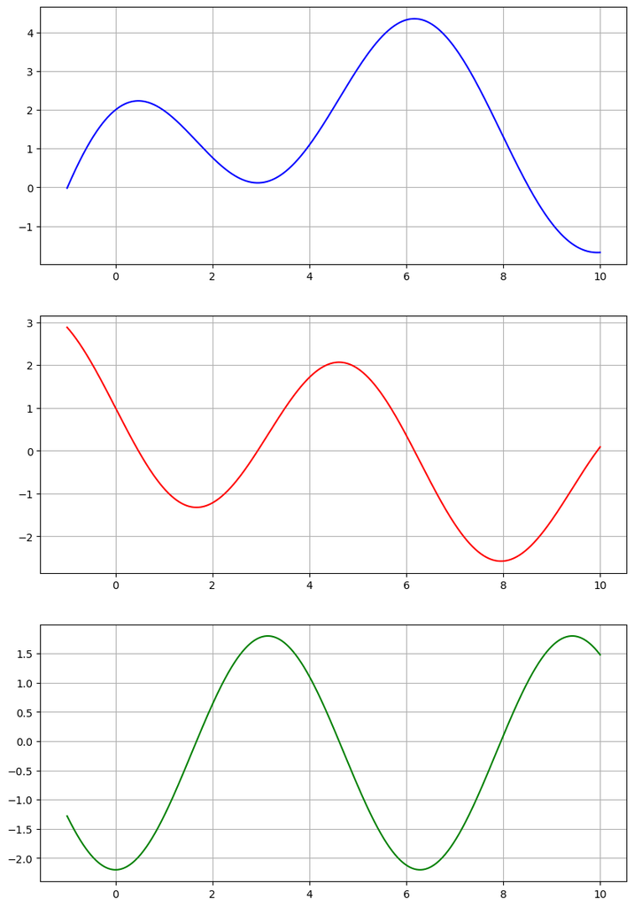

```python
import numpy as np
import matplotlib.pyplot as plt

def f(x):
    return 2 * np.cos(x) + x - x**2/10
def df(x):
    return -2 * np.sin(x) + 1 - x/5
def ddf(x):
    return -2 * np.cos(x) - 1/5

fig, ax = plt.subplots(nrows=3, ncols=1, figsize=(10,15))
x = np.linspace(-1, 10, 1000)
ax[0].plot(x, f(x), c='b')
ax[0].grid()
ax[1].plot(x, df(x), c='r')
ax[1].grid()
ax[2].plot(x, ddf(x), c='g')
ax[2].grid()
plt.show()
```

**최대값**

```
iter1, x = 6.169233, del = 0.169233, func value = 0.000000
iter2, x = 6.166291, del = -0.002942, func value = 4.350318
iter3, x = 6.166290, del = -0.000000, func value = 4.350328
iter4, x = 6.166290, del = -0.000000, func value = 4.350328


x = 6.166290, extreme value = 4.350328
```

**극소값**

```
iter1, x = 3.927261, del = 1.927261, func value = 0.000000
iter2, x = 2.585112, del = -1.342149, func value = 0.971091
iter3, x = 2.967845, del = 0.382733, func value = 0.218593
iter4, x = 2.933560, del = -0.034285, func value = 0.117147
iter5, x = 2.933436, del = -0.000123, func value = 0.116104
iter6, x = 2.933436, del = -0.000000, func value = 0.116104
iter7, x = 2.933436, del = -0.000000, func value = 0.116104


x = 2.933436, extreme value = 0.116104
```

### 예제

#### Chapra Ch.7 PROBLEM 7.35

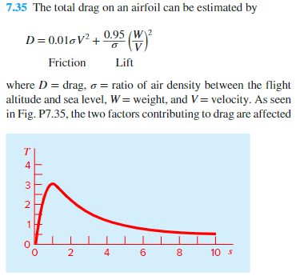

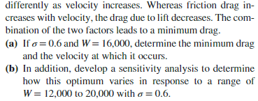

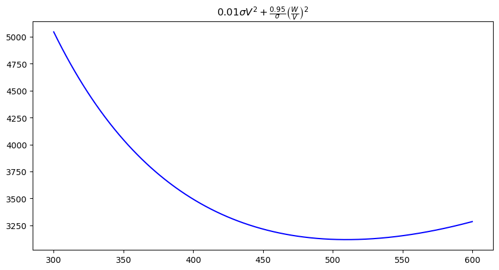

```python
def D(x):
    return 0.01 * 0.6 * x**2 + 0.95/0.6 * (16000/x)**2

x = np.linspace(300, 600, 1000)

plt.figure(figsize=(10,5))
plt.plot(x, D(x), c='b')
plt.title(r'$0.01\sigma V^2 + \frac{0.95}{\sigma}\left(\frac{W}{V} \right)^2$')
plt.show()
```

**황금분할탐색법**

```
#iter35, xm = 509.818121, res = 0.000000, extreme = 3118.974190


xm = 509.818121, extreme value = 3118.974190
```

35회 반복

**뉴턴-랩슨법**

```
iter7, x = 509.818120, del = 0.000000, func value = 3118.974190


x = 509.818120, extreme value = 3118.974190
```

7회 반복

**할선법**

```
iter9, x = 509.818120, del = 0.000000, func value = 3118.974190


x = 509.818120, extreme value = 3118.974190
```

9회 반복

## 다변수 최적화 문제의 수치해석

*Multi-Variable Optimization Problem* p.234

Single-Variable Optimization:

1. Golden-Section Search
2. Newton-Raphson
3. Secant

Multi-Variable Optimization:

- Gradient Method

다변수 최적화 문제에선 헤시안 행렬의 해석이 중요하다.

- 헤시안 행렬의 고유값이 모두 음이면: 최대 또는 극대점 존재
- 헤시안 행렬의 고유값이 모두 양이면: 최소 또는 극소점 존재
- 고유값이 양수와 음수가 섞여 있을 때: 극대, 극소점이 동시에 존재
- 고유값에 0이 섞여 있을 떄: 알 수 없음